# Statistical inference with the GSS data

# Document created by Ricardo Bejarano

## Setup

### Load packages

```r
library(ggplot2)
library(dplyr)
library(statsr)
```

### Load data

```r
load("gss.rdata")
```

## Part 1: Data

The General Social Survey (GSS) is a survey of American adults that registers demographic data and behaviors regarding social and political issues. The survey in question primarily involves face-to-face interviews by professional interviewers of persons living in US households. Over time, various sample methods were used. The two most common methods are full probability random sampling and block quota sampling, a variation of stratified random sampling. During sampling, one adult is randomly selected from each sampled household. Furthermore, the GSS uses large, clearly defined sampling frames that are updated over time so the survey targets a well-defined population that is representative of the target population of US adults. For more information, please click [here](http://gss.norc.org/).

Thanks to these method choices, the GSS claims that its samples closely resemble US population distributions as reported in the National Census. However, several factors like survey non-response, sampling variation, and others can cause the GSS sample to deviate from known population figures for some variables. For example, various sampling frames and methods have underrepresented adult males, certain races, and religious groups in some years. Thus, any conclusions drawn from the data are mostly extendable to US adults with the caveat that there are lingering uncertainties for the external validity of the survey data.

The survey does not involve random assignment of respondents to the factors under consideration because this is an observational study and the concept of random assignment would only apply if this were an experimental study. Any identified associations will be complicated by lurking variables and bias, both measured in the survey and from unmeasured sources. It is impossible to rule out other confounding factors that may affect any discovered associations between the measured variables. Therefore, no causality can be determined from inference on this data, only evidence of for strong associations. Such relationships are useful for hypothesis formation for the design of future studies that can establish causality. Moreover, the relationships present in this data are informative about real world opinions and demographic information to get a glimpse of social features of the US population.

## Part 2: Research question

From the time range in which this survey has taken place, does a different proportion of US adults (who reported living with families with below average incomes when they were sixteen) report an above average income today if they earned any college degree than if they did not earn any college degree?

**Why is this question relevant?**

Economic mobility is a measure of how difficult it is for members of the lowest socioeconomic status to move up to higher status in their lifetime. There are many reasons to be concerned with measures of mobility for analyzing the functioning of a society. High mobility may be desired for those who wish their society to be truly meritocratic, such that how much money one starts with does not change their chance of moving up in socioeconomic status. In addition, from a moral perspective, high mobility may indicate a society successfully provides for its poor. One of the factors suggested to increase mobility is education. In the US, a college education is seen as necessary to make a better living. This question addresses the potential impact of education for individuals that come from poor families to see what impact, if any, a college education may have on future socioeconomic status.

## Part 3: Exploratory data analysis

Before we start working with our exploratory data analysis, we need to work with the data to create the variables that are relevant to this study. The first thing we need to do is select only the relevant variables (using the `select` function) and make sure all rows have data available for each variable (using the `complete.cases` function).

```r
study <- gss %>% select(degree, incom16, finrela)
study <- study[complete.cases(study),]
```

Next, we filter for only respondents with below average family income when they were 16, and mutate the data frame to add the new variables. The basic logic under the following code is:

- We filter those respondents who claim to have income below or far below average;
- We add a new variable called `college`, which will equal `No College Degree` if the respondent’s highest level of education was high school or lower, or `College Degree` if otherwise;
- We add another new variable called `income_today`, which will equal `Above Average` if the respondent’s opinion of family income is above of far above that of other American families’, or `Not Above Average` if otherwise; and,
- We transform the new variables to the type *factor* so we don’t deal with strings.

```r
study <- study %>% filter(incom16 == "Below Average" | incom16 == "Far Below Average") %>% mutate(college = ifelse((degree == "Lt High School" | degree == "High School"), "No College Degree", "College Degree"), income_today = ifelse((finrela == "Far Above Average" | finrela == "Above Average"), "Above Average", "Not Above Average"))
study$college <- factor(study$college)
study$income_today <- factor(study$income_today)
```

Now we focus only on the new variables, which means we disregard all the variables which are not the ones we just created (`college` and `income_today`).

```r
study <- droplevels(study) %>% select(college,income_today)
```

Finally, let’s take a look at what has resulted from these data modifications.

```r
glimpse(study)
```

```
## Observations: 13,171
## Variables: 2
## $ college      <fctr> No College Degree, No College Degree, No College...
## $ income_today <fctr> Above Average, Not Above Average, Not Above Aver...
```

As we can see, we will now work with a data frame which contains: 13,171 observations and 2 categorical variables. Furthermore:

- The variable `college` will tell us if the respondent obtained some level of college degree or not.
- The variable `income_today` will tell us if the respondent claims to have an above average than the rest of the adult US population or not.

We will now try to visualize the data in a more organized way. We will summarize statistics with the `summarise` function.

```r
study %>% group_by(college, income_today) %>% summarise(count = n())
```

```
## # A tibble: 4 x 3
## # Groups:   college [?]
##             college      income_today count
##              <fctr>            <fctr> <int>
## 1    College Degree     Above Average   877
## 2    College Degree Not Above Average  1615
## 3 No College Degree     Above Average  1036
## 4 No College Degree Not Above Average  9643
```

```r
study %>% group_by(college) %>% group_by(income_today) %>% summarise(count = n())
```

```
## # A tibble: 2 x 2
##        income_today count
##              <fctr> <int>
## 1     Above Average  1913
## 2 Not Above Average 11258
```

```r
study %>% group_by(income_today) %>% group_by(college) %>% summarise(count = n())
```

```
## # A tibble: 2 x 2
##             college count
##              <fctr> <int>
## 1    College Degree  2492
## 2 No College Degree 10679
```

As we can see, the results are as follows:

- There are 877 respondents who have some level of college degree and claim to have above average income.
- There are 1,615 respondents who have some level of college degree but don’t claim to have above average income.
- There are 1,036 respondents who don’t have a college degree and claim to have above average income.
- There are 9,643 respondents who neither have a college degree nor claim to have above average income.

We can visualize this better by plotting the data:

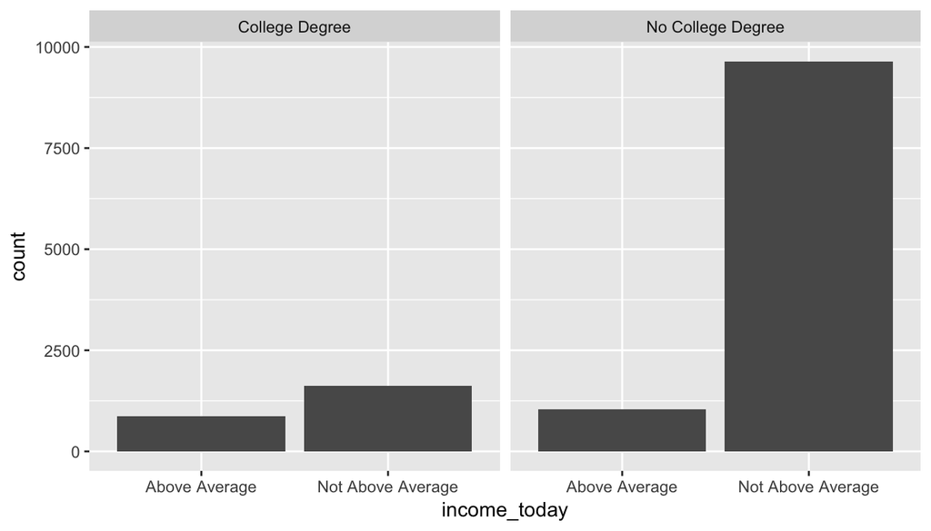

```r
ggplot(study, aes(x = income_today)) + geom_bar() + facet_grid(~college)
```

Now, we want to take a look at proportions within that population. We will use the same basic formulas as above, but this time we will divide by the number of observations. To make this process easier, we will store the number of observations in the data set `study` into a variable called `total`, the total of respondents who have some level of college degree into a variable called `nCollegeYes`, and the total of respondents who don’t have a college degree into a variable called `nCollegeNo`.

```r
nCollegeYes <- strtoi(study %>% filter(college == "College Degree") %>% summarise(sum(n())))
nCollegeNo <- strtoi(study %>% filter(college == "No College Degree") %>% summarise(sum(n())))
study %>% filter(college == "College Degree") %>% group_by(income_today) %>% summarise(proportion = n() / nCollegeYes)
```

```
## # A tibble: 2 x 2
##        income_today proportion
##              <fctr>      <dbl>
## 1     Above Average  0.3519262
## 2 Not Above Average  0.6480738
```

```r
study %>% filter(college == "No College Degree") %>% group_by(income_today) %>% summarise(proportion = n() / nCollegeNo)
```

```
## # A tibble: 2 x 2
##        income_today proportion
##              <fctr>      <dbl>
## 1     Above Average 0.09701283
## 2 Not Above Average 0.90298717
```

From these data, we can see the following.

For those who have some level of college degree:

- 35.19% claim to have an above-average level of income; and,
- 64.81% claim they don’t.

For those who don’t have a college degree:

- 9.70% claim to have an above-average level of income; and,
- 90.30% claim they don’t.

There appears to be a 25.5% difference in those who claim to have an above-average level of income, depending on whether they have some level of college degree or not. This is our variable of interest, and we will plot this information to see this better.

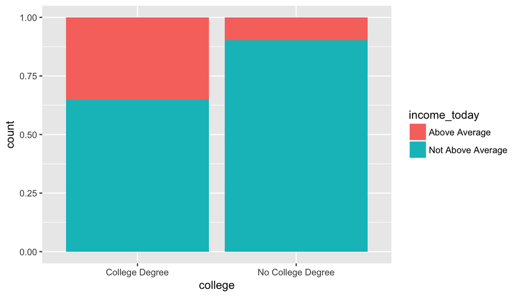

```r
ggplot(study, aes(x = college, fill = income_today)) + geom_bar(position = "fill")
```

As we can see, there is a 25.5% difference between those who claim to have some level of college degree and report having an above-average level of income than those who claimed they don’t have a college degree and report an above-average level of income. This suggests there is an association between having a college degree and reporting an above-average income. We will use statistical inference to determine is such association exists or not.

## Part 4: Inference

Now we need to check whether the conditions are met for statistical inference.

**Condition 1: Does the data represent a random sample?**

Considering the approach the GSS took in random sampling and the population of US adults is at least 10-20 times the sample size, we can assume that yes, the data represents a random sample.

**Condition 2: Does the sampling distribution approach a normal curve?**

When we talk about proportions, this condition is satisfied if we have 10 successes and failures in each of the samples. The numbers we got were 877, 1,036, 1,615, and 9,643, so we can assume that yes, this condition is also met.

**Hypothesis:**

Our null hypothesis in this case will be that *nothing is going on*, which translates into assuming that the proportion of respondents who claim to have a higher-than-average level of income is the same, regardless of whether they had a college education or not. Our alternative hypothesis, on the other hand, will be that there is in fact a difference between the proportion of individuals who claim to have a higher-than-average level of income depending on whether they claim to have gone to college or not. So, for our null hypothesis, the difference between these proportions is equal to 0, whereas for our alternative hypothesis, it will be different than 0.

$$H_0:\hat{p}_1-\hat{p}_2 = 0$$
$$H_a:\hat{p}_1-\hat{p}_2 \neq 0$$

Since we are working with two-level categorical variables, we will use the ‘plus four’ method. For more information on this method, please click [here](https://www.thoughtco.com/what-is-a-plus-four-confidence-interval-3126222).

We already have our `nCollegeNo` and `nCollegeYes` variables. Now we need to assign both our success cases to new variables, which we will call `AboveCollegeYes` and `AboveCollegeNo`.

```r
AboveCollegeYes <- strtoi(study %>% filter(college == "College Degree", income_today == "Above Average") %>% summarise(sum(n())))
AboveCollegeNo <- strtoi(study %>% filter(college == "No College Degree", income_today == "Above Average") %>% summarise(sum(n())))
```

Next, we add 1 and 2 to our variables.

```r
proportion1 <- AboveCollegeYes + 1
total1 <- nCollegeYes + 2
proportion2 <- AboveCollegeNo + 1
total2 <- nCollegeNo + 2
phat1 <- proportion1 / total1
phat2 <- proportion2 / total2
```

```r
phat1
```

```
## [1] 0.3520449
```

```r
phat2
```

```
## [1] 0.09708829
```

- `phat1` is the proportion of adults who earned a college degree and now report above average income.
- `phat2` is the proportion of adults who did not earn a college degree and now report above average income.

Now, we calculate the difference between both our `phat` variables.

```r
pdifference <- phat1 - phat2
pdifference
```

```
## [1] 0.2549566
```

- `pdifference` is the difference in proportions.

Now, we calculate the standard error.

```r
stdError <- sqrt(((((phat1) * (1-phat1)) / (total1))) + (((phat2) * (1-phat2)) / (total2)))
stdError
```

```
## [1] 0.009983513
```

Next, we calculate our 95% confidence intervals, but not before calculating our critical value for a 95% confidence interval.

```r
cv <- qnorm(0.975)
ciLower <- pdifference - cv * stdError
ciUpper <- pdifference + cv * stdError
```

```r
ciLower
```

```
## [1] 0.2353893
```

```r
ciUpper
```

```
## [1] 0.2745239
```

To calculate the significance:

```r
ppool <- (proportion1 + proportion2) / (total1 + total2)
newZ <- pdifference / sqrt(ppool * (1 - ppool) * ((1 / total1) + (1 / total2)))
newZ
```

```
## [1] 32.52686
```

With this z statistic, we calculate the p-value and the relative-risk of one `phat` to the other.

```r
pvalue <- 2 * pnorm(abs(newZ), lower.tail = FALSE)
ratio <- phat1 / phat2
```

```r
pvalue
```

```
## [1] 4.448104e-232
```

```r
ratio
```

```
## [1] 3.626029
```

We can see that the p-value equals 4.45 × 10 to the -232 power, which is very small. So, based on this information, we reject the null hypothesis and conclude the difference in proportions between the two groups is statistically significant.

Further studies should be conducted to establish causality between these two variables.